# Die Power der Prompts

Sinnvolle KI-Projekte in der Zivilgesellschaft

Jonas Stettner | CorrelAid · Civic Data Lab Online Barcamp

19. November 2026

[figure not shown]

[figure not shown]

Diese Präsentation ist lizenziert unter [CC BY 4.0](https://creativecommons.org/licenses/by/4.0/deed.de).  
Davon ausgenommen sind entsprechend gekennzeichnete Fremdinhalte.

## Hallo 👋

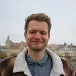

Jonas

Referent bei CorrelAid

Beratungs- und Umsetzungsteam im Civic Data Lab

jonas.s@correlaid.org

## Über CorrelAid

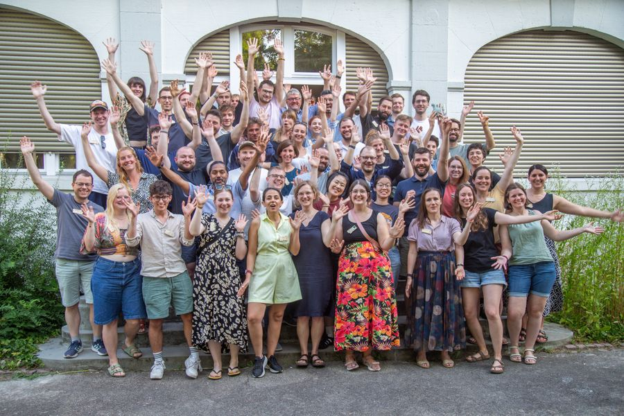

CorrelAid

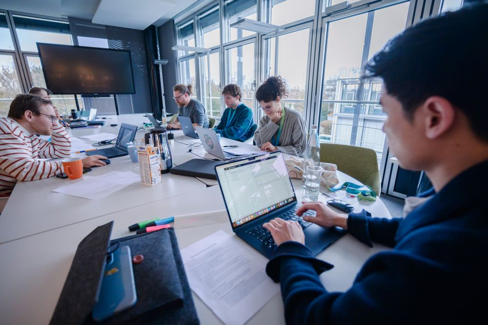

Sascha Schürmann / Salt & Content

CorrelAid hilft Non-Profits dabei, Daten kritisch und reflektiert für ihre Ziele einzusetzen.

**Zivilgesellschaft unterstützen**Pro-bono Data4Good-Projekte und Beratung für Non-Profits

**Datenkompetenz stärken**Weiterbildung für Non-Profits und Ehrenamtliche

**Community fördern**Datenanalyst*innen vernetzen sich online und vor Ort

## Schön, dass ihr da seid!

[figure not shown]

- Die **Folien** findet ihr hier: [correlaid.github.io/power_der_prompts_cdl](https://correlaid.github.io/power_der_prompts_cdl/#/title-slide)
- Lasst uns heute im Workshop gerne beim **Du** bleiben.
- Macht aktiv mit und teilt eure Erfahrungen. Es gibt keine „blöden“ Fragen. Merkt euch eure Fragen: am Ende gibt es Zeit dafür.

## Inhalte

1. 01Ankommen & AktivierungWas kann KI angeblich? · 10 min
2. 02KI als Werkzeug: Tasks, Methoden, PromptsImpuls + Übung: Probleme zu Tasks zuordnen · 19 min
3. 03Ein KI-Projekt durchführen: Voraussetzungen und KostenImpuls: Was es braucht und wer die Kosten trägt · 7 min
4. 04AbschlussAusblick & Fragen · 8 min

## Eine Bewertungsskala

🧙 Mythos ⟵ 🤔 ⟶ 🦊 Fable(haft)

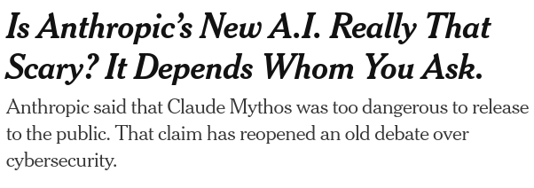

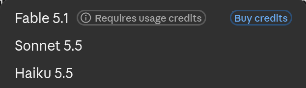

🧙 *Mythos im eigentlichen Sinne* · 🤔 *unsicher (müsste ich ChatGPT fragen)* · 🦊 *keine Fabel, sondern fable(haft)*

The New York Times (2026) · Screenshot: Claude-Modellauswahl, November 2026

## Übung: Vibecheck

1. Denkt an ein **Versprechen über KI**, das ihr gehört habt (Pitch, Werbung, Förderaufruf, Kolleg*in)
2. Tippt es in den **Chat** + ein Emoji von der Skala:

🧙 *Mythos im eigentlichen Sinne* · 🤔 *unsicher (müsste ich ChatGPT fragen)* · 🦊 *keine Fabel, sondern fable(haft)*

3. Chatwasserfall: **Enter erst auf mein Los!**

*Beispiel: „Mit KI spart ihr 10 Stunden pro Woche“ 🧙*

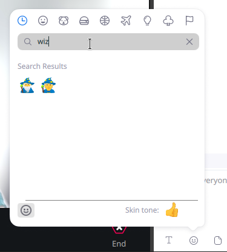

## Was wird versprochen?

- Typische Muster: **Zeit sparen** · **nicht abgehängt werden** · **Effizienz** unter Förderlogiken
- Zwänge in der Zivilgesellschaft: wenig Personal, Projektförderung. Unser Eindruck aus Beratungen: KI-Projekte haben Prestige und bekommen leichter Geld
- Die Kehrseite: Kosten werden verlagert
  - **Workslop**: KI-Output, der nach Arbeit aussieht, die Arbeit aber auf andere verlagert (Umfrage unter US-Büroangestellten)
  - Ressourcenverbrauch, Kognitives Outsourcing, Abhängigkeit: dazu später mehr

Niederhoffer et al. (2025)

## Inhalte

1. 01Ankommen & AktivierungWas kann KI angeblich? · 10 min
2. 02KI als Werkzeug: Tasks, Methoden, PromptsImpuls + Übung: Probleme zu Tasks zuordnen · 19 min
3. 03Ein KI-Projekt durchführen: Voraussetzungen und KostenImpuls: Was es braucht und wer die Kosten trägt · 7 min
4. 04AbschlussAusblick & Fragen · 8 min

## KI als Werkzeug

1. 2.1TasksVon Fähigkeiten zu Aufgaben und echten Projekten
2. 2.2MethodenEin Task, viele Ansätze
3. 2.3PromptsWas Prompts können
4. 2.4MessenEinfache Performancemessung
5. 2.5KriterienWann ist KI sinnvoll? (Teil 1)
6. 2.6ÜbungProbleme zu Tasks zuordnen

## Was ist KI? Intelligenz

> Intelligenz ist der rechnerische Teil der Fähigkeit, Ziele in der Welt zu erreichen. […] Intelligenz umfasst Mechanismen; die KI-Forschung hat herausgefunden, wie Computer **manche davon ausführen können, andere nicht**.

Intelligenz ist also ein **Bündel von Fähigkeiten**: einordnen, lesen, wiederfinden, formulieren, vorausschauen, planen … Manche davon kann *Künstliche* Intelligenz (KI) gut, andere kaum.

McCarthy (2007), eigene Übersetzung

## Von Fähigkeiten zu Tasks

Ein **Task** legt fest: Was geht rein? Was soll rauskommen? Woran messen wir, ob es stimmt?

| Task | Beispiel: Eingabe → Ausgabe | Wie messen? |
| --- | --- | --- |
| ① Klassifikation | E-Mail → zuständige Person | Anteil richtig zugeordnet |
| ② Informationsextraktion | Rechnung → Betrag, Datum, Absender | Anteil korrekter Felder |
| ③ Texterkennung / Spracherkennung | Formular oder Interview-Audio → Text | Anteil falscher Wörter |
| ④ Suche / Fragen beantworten | Frage → passende Dokumente | Richtiges Dokument unter den Top 5? |
| ⑤ Vereinfachen / Umformulieren | Behördenbrief → Leichte Sprache | Prüfung durch Zielgruppe |
| ⑥ Gruppieren (Clustering) | 2.000 Freitextantworten → Themen | Keine richtige Antwort, daher Plausibilität prüfen |
| ⑦ Dubletten erkennen | Spendendatenbank → doppelte Einträge | Anteil gefundener Dubletten |
| ⑧ Vorhersage / Anomalie | Einsatzdaten → Bedarf morgen | Abweichung, Fehlalarme vs. Übersehene |

## Typische KI-Projekte nach Task

| Task | Projekt |
| --- | --- |
| **① Klassifikation** | [AfD-Gutachten](https://www.afd-gutachten.de/gutachten/03-einfuehrung/04-methodik/02-massenhafte-erhebung-von-primaerdaten/01-quellen/): Äußerungen vorfiltern |
|  | [AWO](https://awo.org/projekt/demokratiefoerderung/): Fördert ein Programm Demokratie? |
| **③ Texterkennung** | [genialsozial](https://saechsische-jugendstiftung.de/angebot/genialsozial-aktionstag-einen-tag-arbeiten-und-soziale-projekte-unterstuetzen/): Handschrifterkennung für Formulare |
| **④ Suche / Fragen beantworten** | [Schule ein Gesicht geben](https://civic-data.de/blog/schule-ein-gesicht-geben/): Wissensdatenbank zugänglicher machen |
| **⑤ Vereinfachen** | [Fair Text](https://fair-text.com/assistant-leichte-sprache-uebersetzer/): Texte in Leichte Sprache übersetzen |
| **⑧ Vorhersage / Anomalie** | [BeeObserver](https://correlaid.org/projekte/projektdatenbank/2019-10-BEE): Anomalien im Bienenstock erkennen |

Mehr Projekte: [CDL-Projektsammlung](https://civic-data.de/machen/projektsammlung/) · [CorrelAid-Projektdatenbank](https://correlaid.org/projekte/projektdatenbank)

Civic Data Lab (2026a)

## Was ist KI? Ein Oberbegriff

[figure not shown]

## Ein Task, viele Ansätze

Beispiel-Task ①: **E-Mail → zuständige Person**

Von oben nach unten: aufwendiger, teurer, schwerer zu prüfen

| Ansatz | Komplexität | Wie es funktioniert | Im Beispiel |
| --- | --- | --- | --- |
| **Regeln** | ● | Menschen schreiben Wenn-dann-Regeln | „Rechnung“ im Betreff → Buchhaltung |
| **Klassisches ML** | ●● | Lernt aus gelabelten Beispielen | Lernt aus 1.000 bereits zugeordneten Mails |
| **Finetuning** | ●●● | Vorhandenes Modell mit eigenen Beispielen nachtrainiert | Kleines Sprachmodell mit euren Mails nachtrainiert |
| **Großes Modell + Prompt** | ●●●● | Anweisung und ein paar Beispiele, Modell bleibt unverändert | „Ordne diese Mail einer Person zu: …“ |
| **RAG** | ●●●●● | Modell sucht erst in euren Dokumenten, dann antwortet es | Sucht im Zuständigkeitsplan, dann Zuordnung |
| **Agent** | ●●●●●● | Modell plant Schritte selbst und nutzt Tools | Liest Mail, prüft Vertretungsplan, leitet weiter |

Welcher Ansatz passt, muss man **ausprobieren und prüfen**.

## Was Prompts können

- **Task genau beschreiben**, Kategorien definieren
- **3–5 gelabelte Beispiele** mitgeben, aber nicht aus euren Testfällen
- **Ausgabeformat** festlegen (z.B. nur die Kategorie)
- ⚠️ Kleine Änderungen am Prompt oder ein Modell-Update können die Ergebnisse verschieben, also **neu prüfen** (Sclar et al., 2024)
- ✗ Rollen („Du bist Expert*in …“) helfen nicht verlässlich (Zheng et al., 2024)

Viele Tasks lassen sich heute mit einem großen Modell + **Prompt** lösen, aber nicht immer am besten. Und Performance ist nicht der einzige wichtige Faktor.

## Einfache Performancemessung

**Beispiel:** Ein Sportverein will eingehende Mails automatisch einer Kategorie zuordnen.

Bevor ihr euch auf KI verlasst, ein einfacher Einstieg:

1. **Echte Fälle sammeln**, auch seltene und kritische
2. **Zu zweit einordnen**: Wo seid ihr euch uneinig? Dort sind die Kategorien unklar
3. **Fehler anschauen**: Was geht schief, und wen trifft das?

*Dies ersetzt keine gründliche Evaluation, die notwendig ist, wenn Fehler Menschen schaden können.*

## Grenzfälle (Ground Truth)

**Ground Truth**: die Antwort, die für jeden Fall als richtig festgelegt ist. Damit vergleicht man die Ergebnisse der KI.

**A** Mitgliedschaft · **B** Training & Termine · **C** Spenden & Sponsoring · **D** Sonstiges

| Mail | Passt zu |
| --- | --- |
| ① „Meine Tochter möchte mitmachen. Gibt es ein Probetraining?“ | A oder B |
| ② „Wir möchten nach dem Turnier den Erlös spenden. Zählt das auch als Mitgliedsbeitrag?“ | A oder C |
| ③ „Mein Sohn wird im Training von anderen Kindern gemobbt. An wen kann ich mich wenden?“ | keine, landet in D |

**„Ground Truth“ ist nicht die Wahrheit** Referenz-Labels sind Entscheidungen von Menschen, Kategorien ein vereinfachtes Modell der Wirklichkeit. Gemessen wird immer nur gegen dieses Modell.

## Kriterien: Wann ist KI sinnvoll? (Teil 1)

1. Lässt sich das Problem in **klare Tasks** zerlegen?
2. Reicht etwas **Einfacheres**? Zuerst ohne KI, dann die niedrigste Komplexitätsstufe: Regeln → klassisches ML → Finetuning → Prompt → RAG → Agent
3. Kann man **prüfen**, ob es gut genug funktioniert? Was kosten Fehler?
4. Liegt das eigentliche Problem **woanders** (z. B. Einsamkeit mit einem Chatbot lösen? → systemisches Problem), sodass Technik es nicht löst?

*Kriterien 4/7, später mehr*

## Übung: Welcher Task? (1/3)

*Fiktionales Beispiel: Welcher Task?*

Ein Verein bekommt jeden Monat 300 Belege und Rechnungen als PDF und tippt Betrag, Datum und Absender von Hand in die Buchhaltung ab. Das kostet die Kassenwartin zwei Abende im Monat, Tippfehler fallen erst beim Jahresabschluss auf.

**Tasks:** ① Klassifikation · ② Informationsextraktion · ③ Texterkennung · ④ Suche · ⑤ Vereinfachen · ⑥ Gruppieren · ⑦ Dubletten · ⑧ Vorhersage · ✗ kein KI-Task

*Tippt die Nummer in den Chat. Enter erst auf mein Los!*

**Mögliche Lösung:** ② Informationsextraktion (bei Scans vorher ③) · **Oder einfacher?** Strukturierte E-Rechnungen

## Übung: Welcher Task? (2/3)

*Fiktionales Beispiel: Welcher Task?*

Eine Tafel hat 4.000 Spender*innen in drei Excel-Listen, viele doppelt. Manche bekommen drei Dankesbriefe, andere keinen, und niemand weiß, wie viele Spender*innen es wirklich gibt.

**Tasks:** ① Klassifikation · ② Informationsextraktion · ③ Texterkennung · ④ Suche · ⑤ Vereinfachen · ⑥ Gruppieren · ⑦ Dubletten · ⑧ Vorhersage · ✗ kein KI-Task

*Tippt die Nummer in den Chat. Enter erst auf mein Los!*

**Mögliche Lösung:** ⑦ Dubletten erkennen · **Oder einfacher?** Regeln (gleiche E-Mail, Name + PLZ), künftig eine Liste

## Übung: Welcher Task? (3/3)

*Fiktionales Beispiel: Welcher Task?*

Eine Umfrage unter Ehrenamtlichen liefert 2.000 Freitextantworten. In drei Wochen ist der Bericht an die Förderin fällig, und niemand hat Zeit, alles zu lesen.

**Tasks:** ① Klassifikation · ② Informationsextraktion · ③ Texterkennung · ④ Suche · ⑤ Vereinfachen · ⑥ Gruppieren · ⑦ Dubletten · ⑧ Vorhersage · ✗ kein KI-Task

*Tippt die Nummer in den Chat. Enter erst auf mein Los!*

**Mögliche Lösung:** ⑥ Gruppieren, ohne richtige Antwort (oder ①, wenn Kategorien feststehen) · **Oder einfacher?** Feste Antwortfelder statt Freitext

## Inhalte

1. 01Ankommen & AktivierungWas kann KI angeblich? · 10 min
2. 02KI als Werkzeug: Tasks, Methoden, PromptsImpuls + Übung: Probleme zu Tasks zuordnen · 19 min
3. 03Ein KI-Projekt durchführen: Voraussetzungen und KostenImpuls: Was es braucht und wer die Kosten trägt · 7 min
4. 04AbschlussAusblick & Fragen · 8 min

## Voraussetzungen (I)

- **Daten** (*Womit arbeitet die KI?*): Gibt es genug echte Fälle, z. B. Mails oder Anträge? Sind sie zugänglich, aktuell, dokumentiert? Personenbezogen?
  - KI arbeitet besser mit **strukturierten** Daten, am besten mit **semantischen**: **Metadaten** beschreiben, was Felder bedeuten oder Dokumente enthalten und wie sie zusammenhängen
  - RAG und Agents sind nur so gut wie die **Dokumente**, die sie finden
- **Labels** (*Wer weiß, was richtig ist?*): Fachleute legen für einen Teil der Fälle die richtige Antwort fest, z. B. die Kategorie jeder Mail. Haben sie dafür Zeit?

## Voraussetzungen (II)

- **Fähigkeiten** (*Wer baut und betreut es?*): einrichten und anbinden, mit den Labels messen, Fehler auswerten, anpassen. Im Team oder extern?
- **Infrastruktur** (*Wo läuft es?*): Wer zahlt, wer wartet? Auch noch im zweiten Jahr?
  - KI braucht **Schnittstellen (APIs)** zu euren Systemen

## Was oft vergessen wird

- **Schatten-KI**: Mitarbeitende und Ehrenamtliche kopieren vermutlich schon jetzt Daten in ChatGPT. Eine kurze **interne Richtlinie** kann ein guter erster Schritt sein
- **Rechtliche Pflichten**: DSGVO und EU AI Act gelten auch für Vereine, schon wenn eure Leute ChatGPT nutzen. **Informiert euch!**

## Wer trägt die Kosten?

- **Bias & Diskriminierung**
- **Ressourcenverbrauch**: Rechenzentren insgesamt (nicht nur KI) könnten 2030 so viel Strom brauchen wie Japan heute, knapp 3 % des weltweiten Verbrauchs (International Energy Agency, 2025). Rechenzentren belasten lokal Stromnetz, Wasser und Luft
- **Ausbeutung**: Klickarbeit beim Datenlabeling (Perrigo, 2023)

**Zum Nachlesen**

- **Cognitive Outsourcing**: Ersetzt KI Denkprozesse? (Jose et al., 2025)
- **Big Tech**: Machtkonzentration, politische Agenda (Kak & Myers West, 2023)

## Kriterien: Wann ist KI sinnvoll? (Teil 2)

*1–4:* klarer Task? · reicht etwas Einfacheres? · prüfbar, ob es gut genug ist? · Problem liegt woanders?

5. Sind **Daten, Labels, Fähigkeiten und Infrastruktur** vorhanden?
6. Ist der **rechtliche Rahmen** geklärt (Datenschutz, EU AI Act) und sind **Betroffene** beteiligt?
7. Stehen Nutzen und **externalisierte Kosten** in einem vertretbaren Verhältnis?

## Inhalte

1. 01Ankommen & AktivierungWas kann KI angeblich? · 10 min
2. 02KI als Werkzeug: Tasks, Methoden, PromptsImpuls + Übung: Probleme zu Tasks zuordnen · 19 min
3. 03Ein KI-Projekt durchführen: Voraussetzungen und KostenImpuls: Was es braucht und wer die Kosten trägt · 7 min
4. 04AbschlussAusblick & Fragen · 8 min

## Mitnehmen

Statt *„Wie können wir KI einsetzen?“* lieber *„Welches Problem haben wir?“*

1. Lässt sich das Problem in **klare Tasks** zerlegen?
2. Reicht etwas **Einfacheres**? Zuerst ohne KI, dann die niedrigste Komplexitätsstufe: Regeln → klassisches ML → Finetuning → Prompt → RAG → Agent
3. Kann man **prüfen**, ob es gut genug funktioniert? Was kosten Fehler?
4. Liegt das eigentliche Problem **woanders** (z. B. Einsamkeit mit einem Chatbot lösen? → systemisches Problem), sodass Technik es nicht löst?
5. Sind **Daten, Labels, Fähigkeiten und Infrastruktur** vorhanden?
6. Ist der **rechtliche Rahmen** geklärt (Datenschutz, EU AI Act) und sind **Betroffene** beteiligt?
7. Stehen Nutzen und **externalisierte Kosten** in einem vertretbaren Verhältnis?

## Weiterführend

- **Code of Conduct Demokratische KI**: acht Prinzipien für KI in der Zivilgesellschaft: [demokratische-ki.de](https://demokratische-ki.de/)
- **Workshop: KI-Leitlinien für euren Verein**: Do., 3. Dezember, 17:00–18:30 Uhr, online  
  Erste Bausteine für eigene Leitlinien, mit Vorlagen und Beispielen  
  Anmeldung: correlaid.org/veranstaltungen/ws-ki-5

# Zeit für Fragen

Tiefergehende Fragen zu eurem Projekt? Bucht euch einen kostenlosen Termin in der **Datensprechstunde**: zeeg.me/correlaid/dss-cdl

## Quellen

Becker, J., Rush, N., Barnes, E., & Rein, D. (2025). *Measuring the Impact of Early-2025 AI on Experienced Open-Source Developer Productivity*. https://arxiv.org/abs/2507.09089

Benamor, S. (2026, Juli 23). *Grenzen der Verbotsprognose: Über Chancen und Grenzen von Gutachten zur Verfassungswidrigkeit der AfD*. Verfassungsblog. https://verfassungsblog.de/grenzen-der-verbotsprognose/

Brown, T. B., Mann, B., Ryder, N., Subbiah, M., Kaplan, J., et al. (2020). Language Models are Few-Shot Learners. *Advances in Neural Information Processing Systems*, *33*, 1877–1901.

Bucher, M. J. J., & Martini, M. (2024). *Fine-Tuned ’Small’ LLMs (Still) Significantly Outperform Zero-Shot Generative AI Models in Text Classification*. https://arxiv.org/abs/2406.08660

Buolamwini, J., & Gebru, T. (2018). Gender Shades: Intersectional Accuracy Disparities in Commercial Gender Classification. *Proceedings of the 1st Conference on Fairness, Accountability and Transparency*, *81*, 77–91.

Civic Data Lab. (2026a). *Datenprojekte: Sammlung gemeinwohlorientierter Datenprojekte*. Civic Data Lab. https://github.com/Caritas-Deutschland-Digitallabor/datenprojekte

Civic Data Lab. (2026b, August 17). *KI im Ehrenamt – Auswertung einer Umfrage mit digital verein(t)*. Civic Data Lab. https://civic-data.de/machen/begleitete-projekte/ki-im-ehrenamt-auswertung-einer-umfrage/

Civic Data Lab. (2026c, August 17). *K(l)ein Geld für Demokratie?! – Demokratieförderquote*. Civic Data Lab. https://civic-data.de/machen/begleitete-projekte/demokratiefoerderquote/

Devlin, J., Chang, M.-W., Lee, K., & Toutanova, K. (2019). BERT: Pre-training of Deep Bidirectional Transformers for Language Understanding. *Proceedings of the 2019 Conference of the North American Chapter of the Association for Computational Linguistics (NAACL-HLT)*, 4171–4186. https://doi.org/10.18653/v1/N19-1423

Grinsztajn, L., Oyallon, E., & Varoquaux, G. (2022). Why do tree-based models still outperform deep learning on typical tabular data? *Advances in Neural Information Processing Systems 35 (NeurIPS 2022), Datasets and Benchmarks Track*. https://arxiv.org/abs/2207.08815

Hofmann, V., Kalluri, P. R., Jurafsky, D., & King, S. (2024). AI generates covertly racist decisions about people based on their dialect. *Nature*, *633*, 147–154. https://doi.org/10.1038/s41586-024-07856-5

International Energy Agency. (2025). *Energy and AI*. IEA. https://www.iea.org/reports/energy-and-ai

Jose, B., Joseph, D., Mohan, V., Alexander, E., Varghese, S. K., & Roy, A. (2025). Outsourcing cognition: The psychological costs of AI-era convenience. *Frontiers in Psychology*, *16*, 1645237. https://doi.org/10.3389/fpsyg.2025.1645237

Kak, A., & Myers West, S. (2023). *AI Now 2023 Landscape: Confronting Tech Power*. AI Now Institute. https://ainowinstitute.org/2023-landscape

Keymolen, E., & van der Haak, D. (2026). Artificial intentions: Winner’s inherently political artifacts, AI and government. In A. Fox & D. Cressman (Hrsg.), *Arrangements of power: Tracing Langdon Winner’s legacy within and beyond the philosophy of technology*. Springer. https://doi.org/10.1007/978-3-032-17371-3_2

LeCun, Y., Bengio, Y., & Hinton, G. (2015). Deep learning. *Nature*, *521*(7553), 436–444. https://doi.org/10.1038/nature14539

McCarthy, J. (2007, November 12). *What is Artificial Intelligence?* Stanford University. http://jmc.stanford.edu/articles/whatisai/whatisai.pdf

Morozov, E. (2013). *To Save Everything, Click Here: The Folly of Technological Solutionism*. PublicAffairs.

Niederhoffer, K., Kellerman, G. R., Lee, A., Liebscher, A., Rapuano, K., & Hancock, J. T. (2025, September 22). *AI-Generated „Workslop“ Is Destroying Productivity*. Harvard Business Review. https://hbr.org/2025/09/ai-generated-workslop-is-destroying-productivity

Perrigo, B. (2023, Januar 18). *Exclusive: OpenAI Used Kenyan Workers on Less Than $2 Per Hour to Make ChatGPT Less Toxic*. TIME. https://time.com/6247678/openai-chatgpt-kenya-workers/

Sclar, M., Choi, Y., Tsvetkov, Y., & Suhr, A. (2024). Quantifying Language Models’ Sensitivity to Spurious Features in Prompt Design or: How I learned to start worrying about prompt formatting. *The Twelfth International Conference on Learning Representations (ICLR 2024)*. https://arxiv.org/abs/2310.11324

The New York Times. (2026, Mai 12). *Is Anthropic’s New A.I. Really That Scary? It Depends Whom You Ask.* The New York Times. https://www.nytimes.com/2026/05/12/technology/anthropic-claude-mythos.html

Zheng, M., Pei, J., Logeswaran, L., Lee, M., & Jurgens, D. (2024). When "A Helpful Assistant" Is Not Really Helpful: Personas in System Prompts Do Not Improve Performances of Large Language Models. *Findings of the Association for Computational Linguistics: EMNLP 2024*.